# Gestión credenciales

ixpantia

2022-07-01

# **¿Dónde puedo obtener mis credenciales**

Si se ha preguntado dónde puede obtener su token API o no está seguro de la dirección url, el nombre del proyecto ‘upstream’, el nombre del repositorio ixplorer o el nombre del usuario, este vignette le ayudará a obtenerlos.

## Obteniendo el token API

Lo primero que tiene que hacer es ir a la sección de **configuración** que está debajo del avatar de su cuenta.

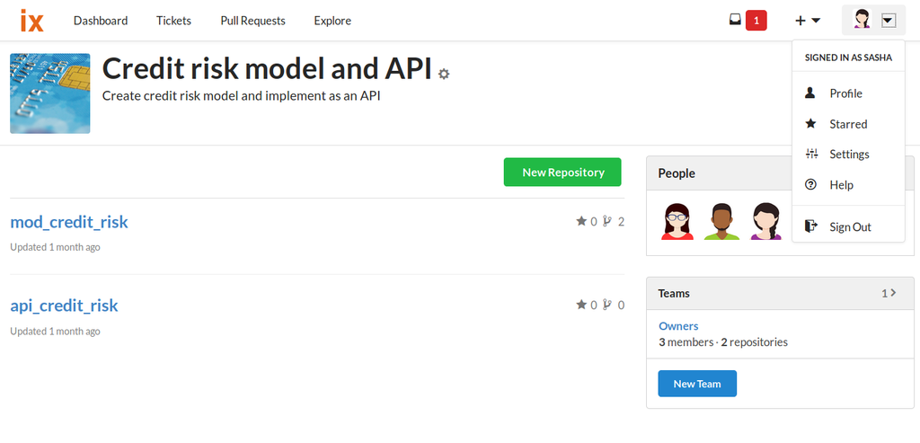

Una vez allí se encuentra una pestaña con el nombre de **aplicaciones**. Se debe de hacer click en esta opción y así la opción de generar un token API estará disponible. Para obtenerlo hay que colocarle un nombre al API y luego crearlo.

[figure not shown]

Después de hacer click en **Generar token** usted verá un número compuesto de varios dígitos. Este es el token API. Asegúrese de anotarlo y guardarlo en algún sitio ya que es la credencial que usted necesitará colocar en el **gadget de autentificación** para lograr acceder a los datos de su repositorio desde RStudio.

[figure not shown]

## Obteniendo el url del ixplorer

Este segmento es simple ya que sólamente es necesario buscar su entorno ixplorer en internet y copiar el url.

Como ejemplo, la credencial url del ixplorer de la imagen abajo mostrada sería:

- https://prueba.ixpantia.com

[figure not shown]

## Nombre del proyecto upstream

[figure not shown]

## Repositorio

Cuando se inicia la sesión, basicamente estará enfocado en un sólo repositorio. Si continuamos con el ejemplo, tenemos dos repositorios bajo *Credit risk model and API*: **mod_credit_risk** y **api_credit_risk**.

Si queremos trabajar en el repositorio **mod_credit_risk** tenemos que escribir este nombre en el gadget de autentificación.

[figure not shown]

## Nombre de usuario

En este punto corresponde solamente el nombre del usuario que se utiliza para ingresar a la cuenta de su entorno ixplorer. En este ejemplo tendríamos por nombre a la usuaria **sasha**

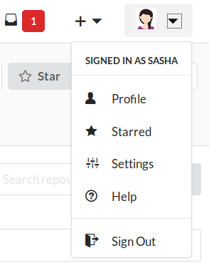

## ¿Cómo luciría el gadget de autentificación?

El gadget actualmente cuenta con 6 espacios totales para llenar. La primera vez que usted accesa el gadget mediante el addin en Addins o la función add_token(), este se despliega únicamente preguntando por el url de su entorno ixplorer. En caso de que se detecte que no hay credenciales previamente ingresadas para su entorno, se desplegaran los siguientes espacios preguntado por su token, nombre de usuario, nombre y repositorio. Además existe la opción adicional para elegir su idioma de preferencia. Posteriormente los gadgets que se llamen van a ser desplegados en este idioma. El gadget entonces se vería como la imagen de abajo

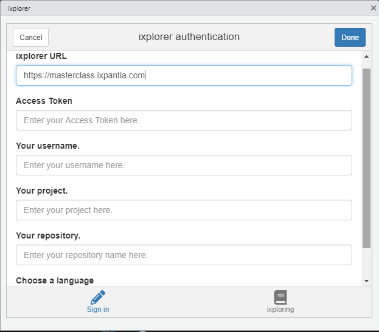

Cuando ya existen credenciales previamente guardadas para el entorno de su url se le dirigirá a la segunda pestaña del gadget, “ixploring” donde podrá seleccionar uno de sus entornos previamente seleccionados, cambiar su proyecto y posteriormente su repositorio. Esta pestaña luciría como la imagen de abajo.

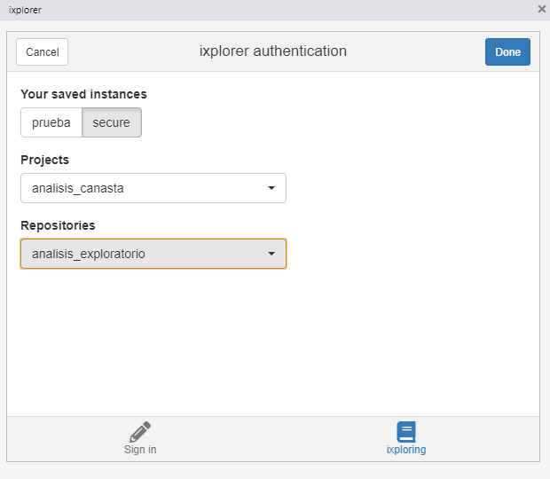

Una vez que el gadget de autentificación se cierre es probable que se le pida ingresar una contraseña. Este contraseña puede ser requerida para su instancia la próxima vez que usted utilice alguna función de ixplorer, por lo que se recomienda almacenarla debidamente en un gestor de contraseñas de su computadora. Este paso es especialmente importante para quienes utilizan un computador compartido.

Si su intención no es guardar las credenciales permanentemente en la computadora siempre puede eliminarlas una vez que su sesión de trabajo haya terminado. Para esto se utiliza la funcion elminar_credenciales o bien delete_credentials().